# Qualitative meta-analysis results

Amanida R package

23 March, 2022

## Data exploration

Data is loaded using `amanida_read` function:

```r
coln = c("Compound Name", "Behaviour", "References")
input_file <- system.file("extdata", "dataset2.csv", package = "amanida")
datafile <- amanida_read(input_file, mode = "qual", coln, separator=";")
```

Your data:

```
## Loaded dataset with 161 rows which contains 131 different identifiers. There are 18 rows skipped from original dataset because contained NA values.
```

Here is shown the imported table:

Table 1: Data exploration

| ID | Behaviour | Reference |
| --- | --- | --- |
| Citric acid | Up-regulated | [24] Deng 2019 |
| Citric acid | Down-regulated | [33] Cheng 2012 |
| Citric acid | Down-regulated | [34] Kim 2019 |
| Citric acid | Down-regulated | [42] Qiu 2010 |
| Citric acid | Down-regulated | [42] Qiu 2010 |
| Citric acid | Up-regulated | [43] Liesenfeld 2015 |
| Hippuric acid | Down-regulated | [24] Deng 2019 |
| Hippuric acid | Down-regulated | [33] Cheng 2012 |
| Hippuric acid | Down-regulated | [34] Kim 2019 |
| Hippuric acid | Down-regulated | [42] Qiu 2010 |
| Indole-3-acetic acid | Down-regulated | [24] Deng 2019 |
| Indole-3-acetic acid | Down-regulated | [33] Cheng 2012 |
| Indole-3-acetic acid | Down-regulated | [43] Liesenfeld 2015 |
| P-Cresol | Down-regulated | [33] Cheng 2012 |
| P-Cresol | Down-regulated | [42] Qiu 2010 |
| P-Cresol | Up-regulated | [42] Qiu 2010 |
| 2-Aminobutyrate | Up-regulated | [33] Cheng 2012 |
| 2-Aminobutyrate | Up-regulated | [43] Liesenfeld 2015 |
| Guaiacol | Down-regulated | [29] Porto-Figueira 2018 |
| Guaiacol | Down-regulated | [43] Liesenfeld 2015 |
| L-Histidine | Down-regulated | [42] Qiu 2010 |
| L-Histidine | Up-regulated | [42] Qiu 2010 |
| L-Pyroglutamic acid | Up-regulated | [42] Qiu 2010 |
| L-Pyroglutamic acid | Up-regulated | [42] Qiu 2010 |
| L-Threonine | Down-regulated | [34] Kim 2019 |
| L-Threonine | Up-regulated | [42] Qiu 2010 |
| L-Tryptophan | Down-regulated | [33] Cheng 2012 |
| L-Tryptophan | Up-regulated | [42] Qiu 2010 |
| L-Tryptophan | Up-regulated | [42] Qiu 2010 |
| L-Tyrosine | Down-regulated | [33] Cheng 2012 |

[output cut: 131 more lines]

## Qualitative analysis

Qualitative analysis is performed by the vote-counting computed as follows: for compounds up-regulated are count as +1 and for down-regulated as -1. Total sum is obtained for each compound.

```r
vote_results <- amanida_vote(datafile, comp.inf = params$comp_inf)
```

```r
vote_results@vote
```

Table 3: Qualitative analysis

| ID | Votes | articles |
| --- | --- | --- |
| Hippuric acid | -4 | 4 |
| Indole-3-acetic acid | -3 | 3 |
| 2-Aminobutyrate | 2 | 2 |
| Citric acid | -2 | 6 |
| Creatinine | -2 | 2 |
| Guaiacol | -2 | 2 |
| L-Pyroglutamic acid | 2 | 2 |
| N1,N12-Diacetylspermine | 2 | 2 |
| Phenol | -2 | 2 |
| Putrescine | 2 | 2 |
| Salicyluric acid | -2 | 2 |
| 1,1,6-Trimethyl-1,2-dihydronaphthalene | -1 | 1 |
| 1,3-Dithiane | 1 | 1 |
| 1,5,5-Trimethyl-6-methylene-cyclohexene | -1 | 1 |
| 1,6,7-Trimethylnaphthalene | -1 | 1 |
| 2-Aminohexanedioic acid | -1 | 1 |
| 2-Bromo-4-tert-butylphenol | -1 | 1 |
| 2-Ethyl-5-methylfuran | -1 | 1 |
| 2-Hydroxyestradiol | -1 | 1 |
| 2-Hydroxyglutaric acid | 1 | 1 |
| 2-Methyl-1,3-pentadiene | -1 | 1 |
| 2-Methylfuran | -1 | 1 |
| 2-O-(alpha-D-glucopyranosyl)glycerol | -1 | 1 |
| 2,2,6-Trimethylcyclohexanone | -1 | 1 |
| 2,3-Butanediol | -1 | 1 |
| 2,3-Dihydroxybutanoic acid | 1 | 1 |
| 3-(3-Hydroxyphenyl)-3-hydroxypropanoic acid | -1 | 1 |
| 3-Aminoisobutyrate | 1 | 1 |
| 3-Hexanone | 1 | 1 |
| 3-Hydroxybutyric acid | 1 | 1 |

[output cut: 101 more lines]

```
## Cut-off for votes is 2.
```

[figure not shown]

```r
vote_plot(vote_results, counts = params$votecount_lim)
```

*Note: Plots are limited to 30 compounds for readability, for complete plot download from ubidi.shinyapps.io/easy-amanida*

Here, the explore_plot will only display the relevant identifiers (elements bigger than 2 votes) or those with discrepancies between studies.

As dataset is big, on the following plot will be only displayed elements bigger than 2 votes and the elements with discrepancies between studies:

```
## Cut-off for votes is 2.
```

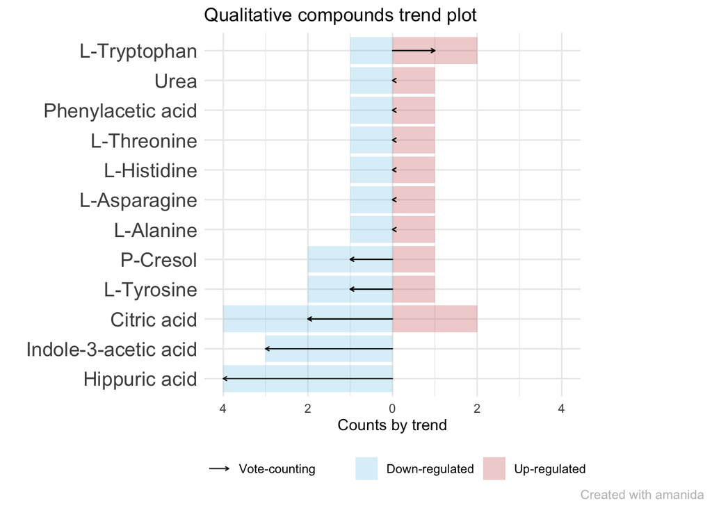

```r
explore_plot(datafile, type = "mix", params$votecount_lim)
```

*Note: Plots are limited to 30 compounds for readability, for complete plot download from ubidi.shinyapps.io/easy-amanida*

*Qualitative analysis using Amanida R package*